# E21009 E21023

Lalit Kumar, Umesh Pachpute

22/06/2021

## Introduction:-

Attrition data for a company is given which includes data of around 1500 people and with 20 features.

## Objective:-

On the given data set, we have to perfrom EDA to find out the possible reasons/features for the attrition observed. This analyis might help us predict whether a person will leave the company or not.

```r
# setting working directory
setwd("C:\\Users\\umesh\\Desktop\\Praxis BS\\2nd Term\\Intro to R programming\\Midterm exam")
#reading the file
att <- read.csv("attrition.csv")
```

```r
#viewing the data in the file
View(att)
```

```r
#checking dimension
dim(att)
```

```
## [1] 1470   20
```

```r
#names of the columns
names(att)
```

```
##  [1] "Age"                     "Attrition"
##  [3] "BusinessTravel"          "Department"
##  [5] "EducationField"          "EnvironmentSatisfaction"
##  [7] "Gender"                  "JobInvolvement"
##  [9] "JobLevel"                "JobSatisfaction"
## [11] "MaritalStatus"           "MonthlyIncome"
## [13] "OverTime"                "TotalWorkingYears"
## [15] "WorkLifeBalance"         "YearsAtCompany"
## [17] "YearsInCurrentRole"      "YearsSinceLastPromotion"
## [19] "YearsWithCurrManager"    "DistanceFromHome"
```

```r
#checking for any missing values in the data
colSums(is.na(att))
```

```
##                     Age               Attrition          BusinessTravel
##                       0                       0                       0
##              Department          EducationField EnvironmentSatisfaction
##                       0                       0                       0
##                  Gender          JobInvolvement                JobLevel
##                       0                       0                       0
##         JobSatisfaction           MaritalStatus           MonthlyIncome
##                       0                       0                       0
##                OverTime       TotalWorkingYears         WorkLifeBalance
##                       0                       0                       0
##          YearsAtCompany      YearsInCurrentRole YearsSinceLastPromotion
##                       0                       0                       0
##    YearsWithCurrManager        DistanceFromHome
##                       0                       0
```

```r
#summary table of the data
summary(att)
```

```
##       Age          Attrition      BusinessTravel      Department
##  Min.   :18.00   Min.   :0.0000   Length:1470        Length:1470
##  1st Qu.:30.00   1st Qu.:0.0000   Class :character   Class :character
##  Median :36.00   Median :0.0000   Mode  :character   Mode  :character
##  Mean   :36.92   Mean   :0.1612
##  3rd Qu.:43.00   3rd Qu.:0.0000
##  Max.   :60.00   Max.   :1.0000
##  EducationField     EnvironmentSatisfaction    Gender          JobInvolvement
##  Length:1470        Min.   :1.000           Length:1470        Min.   :1.00
##  Class :character   1st Qu.:2.000           Class :character   1st Qu.:2.00
##  Mode  :character   Median :3.000           Mode  :character   Median :3.00
##                     Mean   :2.722                              Mean   :2.73
##                     3rd Qu.:4.000                              3rd Qu.:3.00
##                     Max.   :4.000                              Max.   :4.00
##     JobLevel     JobSatisfaction MaritalStatus      MonthlyIncome
##  Min.   :1.000   Min.   :1.000   Length:1470        Min.   : 1009
##  1st Qu.:1.000   1st Qu.:2.000   Class :character   1st Qu.: 2911
##  Median :2.000   Median :3.000   Mode  :character   Median : 4919
##  Mean   :2.064   Mean   :2.729                      Mean   : 6503
##  3rd Qu.:3.000   3rd Qu.:4.000                      3rd Qu.: 8379
##  Max.   :5.000   Max.   :4.000                      Max.   :19999
##    OverTime         TotalWorkingYears WorkLifeBalance YearsAtCompany
##  Length:1470        Min.   : 0.00     Min.   :1.000   Min.   : 0.000
##  Class :character   1st Qu.: 6.00     1st Qu.:2.000   1st Qu.: 3.000
##  Mode  :character   Median :10.00     Median :3.000   Median : 5.000
##                     Mean   :11.28     Mean   :2.761   Mean   : 7.008
##                     3rd Qu.:15.00     3rd Qu.:3.000   3rd Qu.: 9.000
##                     Max.   :40.00     Max.   :4.000   Max.   :40.000
##  YearsInCurrentRole YearsSinceLastPromotion YearsWithCurrManager
##  Min.   : 0.000     Min.   : 0.000          Min.   : 0.000
##  1st Qu.: 2.000     1st Qu.: 0.000          1st Qu.: 2.000
##  Median : 3.000     Median : 1.000          Median : 3.000
##  Mean   : 4.229     Mean   : 2.188          Mean   : 4.123
##  3rd Qu.: 7.000     3rd Qu.: 3.000          3rd Qu.: 7.000
##  Max.   :18.000     Max.   :15.000          Max.   :17.000
##  DistanceFromHome
##  Min.   : 1.000
##  1st Qu.: 2.000
##  Median : 7.000
##  Mean   : 9.193
##  3rd Qu.:14.000
##  Max.   :29.000
```

### HYPOTHESIS 1 :-

#### Age could be a factor for attrition but which age group is the question here.Is there any pattern or equally distributed across all ages.We are assuming that higher age people will have high attrition rate.

Null Hyp = Higher age group people having higher attrition rate

ALternate Hyp < > Higher age group people does not have higher attrition rate

Approach - Plotting graph for attrition=1(left company) against age to see which age group is more contributing to the attrition.

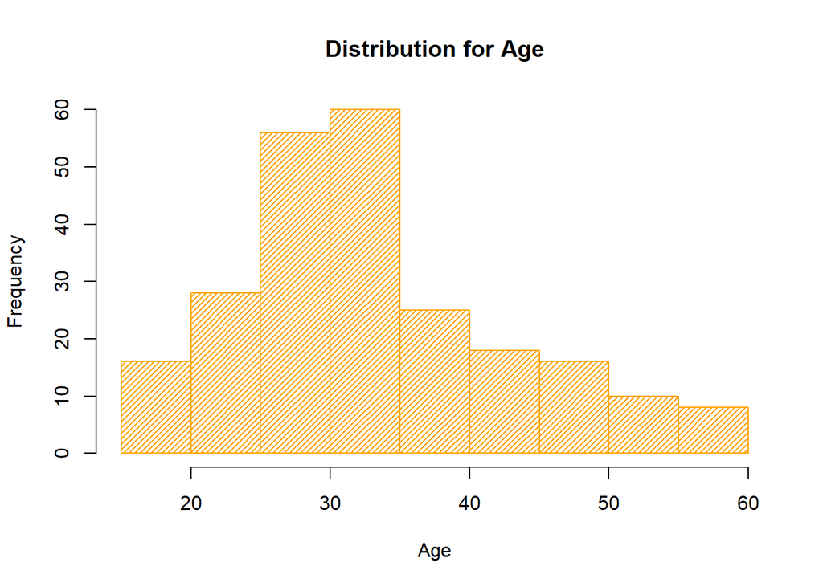

```r
#hist plot for age and attrition=1
hist(att$Age[att$Attrition == 1], xlab = 'Age', main = 'Distribution for Age', col = "orange",density=30)
```

Arguments: After analysising the graph we observe that age group from 25 to 35, are having higher attrition rate, so the null hypothesis is rejected

### HYPOTHESIS 2:-

#### Gender could be a factor

Null Hyp = Male will have high attrition rate

ALternate Hyp < > Male will not have high attrition rate

Approach - Analysis using barplot

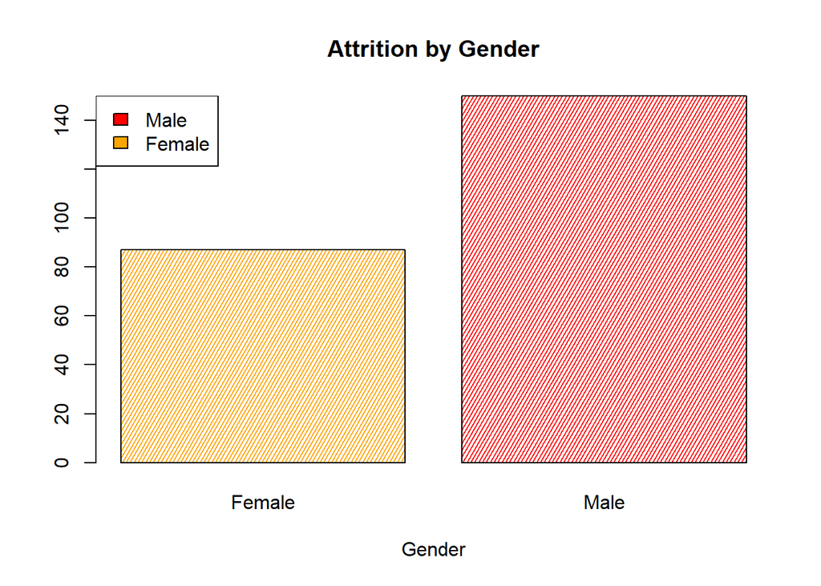

```r
#barplot plot for age and attrition=1
barplot(table(att$Gender[att$Attrition == 1]), xlab = 'Gender', main = 'Attrition by Gender', col = c("orange","red"),density = 35, angle = 60, width = c(0.3,0.3))

legend("topleft",
c("Male","Female"),
fill = c("red","Orange")
)
```

Arguments: Null hypotethesis is accepted

### HYPOTHESIS 3:-

#### Distance From Home could also be a factor. We are assumming that the people who live far away from the office may have more attrition rate

Null Hyp = Long distance people having high attrition

ALternate Hyp < > Short distance people having high attrition

Approach - Using Barplot

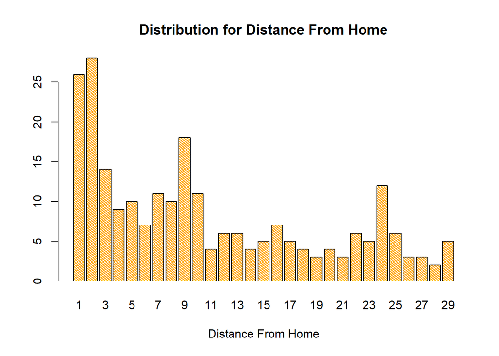

```r
#barplot plot for "DistanceFromHome" and attrition=1
barplot(table(att$DistanceFromHome[att$Attrition == 1]), xlab = 'Distance From Home', main = 'Distribution for Distance From Home', col = "orange",density = 50, angle = 30)
```

Arguments: we can observe from the graph that people having short distance i.e 1 and 2 km are having more attrition rate , so Null Hypotethesis rejected

### HYPOTHESIS 4:-

#### MaritalStatus can be affect the attrition rate

Null Hyp = Single people having more attrition rate

ALternate Hyp < > Single people does not have more attrition rate

Approach - Using Barplot

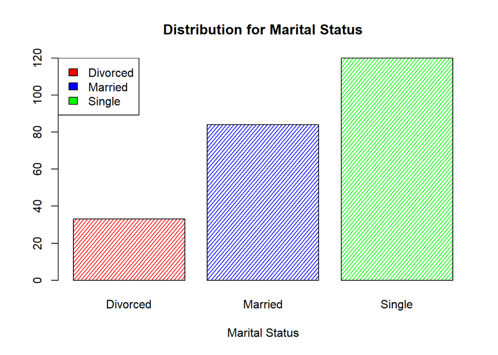

```r
barplot(table(att$MaritalStatus[att$Attrition == 1]), xlab = 'Marital Status', main = 'Distribution for Marital Status', col = c("Red","Blue", "Green"),density = 25, angle = 50)
legend("topleft",
c("Divorced","Married","Single"),
fill = c("red","Blue", "Green")
)
```

Arguments : Null hypotethesis accepted

### HYPOTHESIS 5:-

#### MonthlyIncome

Null Hyp = People having low income group might have high attrition rate ALternate Hyp < > People having low income group does not have high attrition rate

Approach - Scatterplot

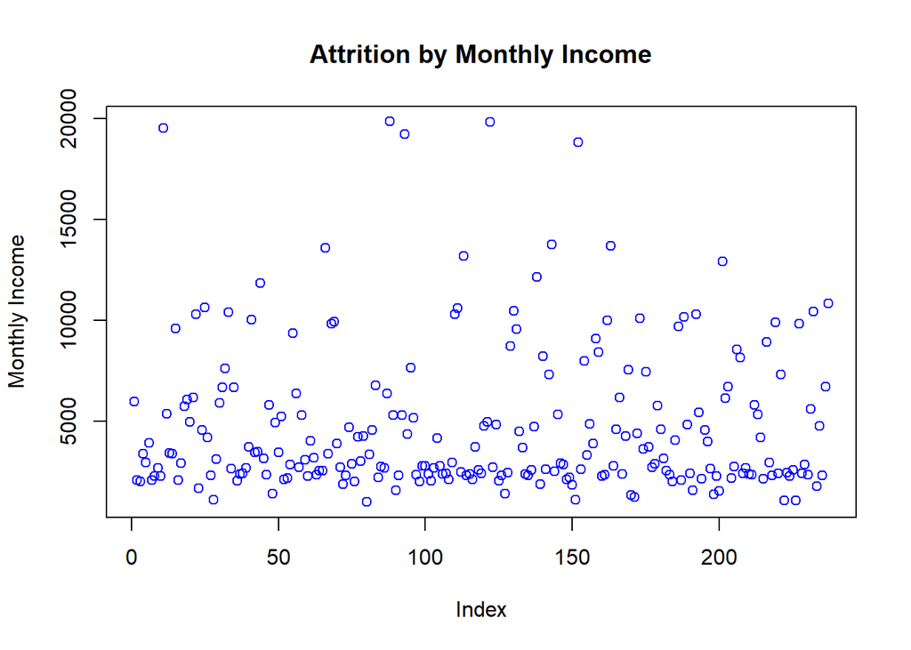

```r
plot(att$MonthlyIncome[att$Attrition == 1],  ylab = 'Monthly Income', main = 'Attrition by Monthly Income', col ="Blue")
```

Arguments : Null Hypothesis Accepted

### HYPOTHESIS 6:-

#### JobSatisfaction

Null Hyp = Employee having less satisfaction might have more attrition

ALternate Hyp < > Employee having less satisfaction does not have more attrition

Approach - Using Barplot

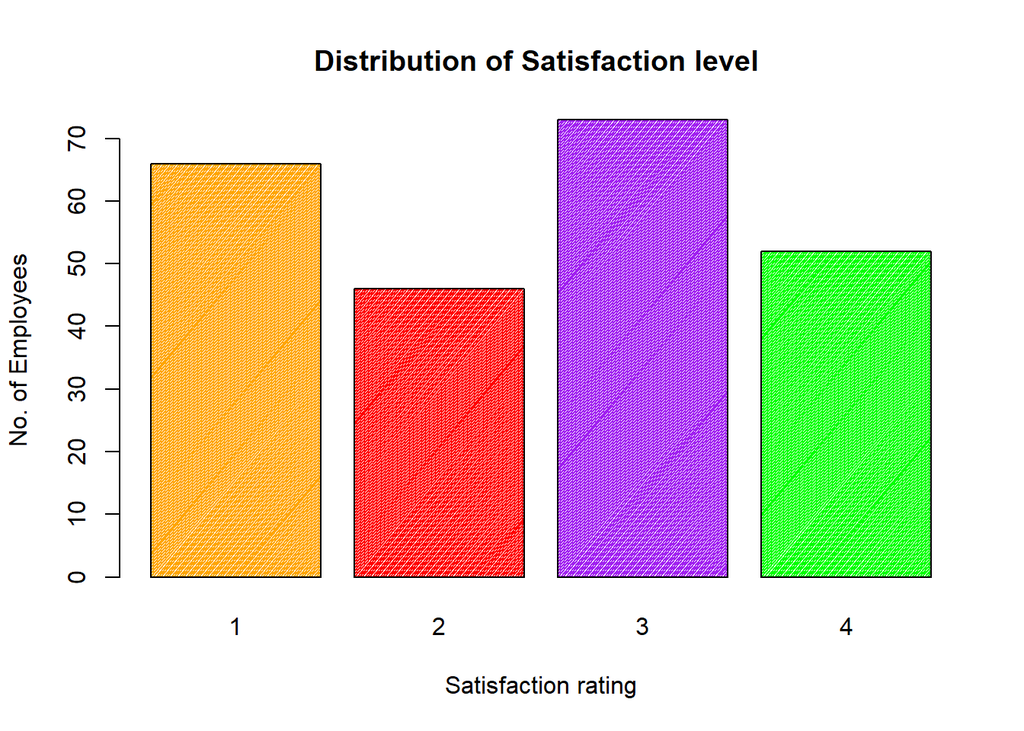

```r
barplot(table(att$JobSatisfaction[att$Attrition == 1]),  ylab = 'No. of Employees',xlab= "Satisfaction rating", main = 'Distribution of Satisfaction level ', col =c("Orange","Red","Purple","Green"),density = 75, angle = 50)
```

Arguments: From the above graph we observed that irrespective of the satisfaction rating level attrition rate are somewhat equally distributed

### HYPOTHESIS 7:-

#### Attrition by Department

Null Hyp = Employees having Research and Development might have high attrition rate

ALternate Hyp < > Employees having Research and Development might have low attrition rate

Approach - Using Barplot for this

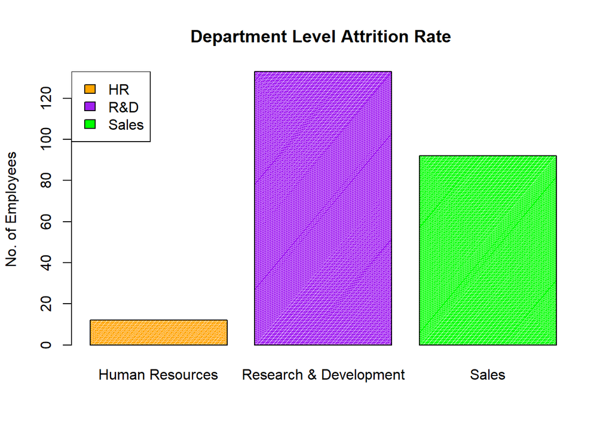

```r
barplot(table(att$Department[att$Attrition == 1]),  ylab = 'No. of Employees',
        main = 'Department Level Attrition Rate ',
        col =c("Orange","Purple","Green"),density = 75, angle = 50)

legend("topleft",
c("HR","R&D","Sales"),
fill = c("Orange","Purple","Green"))
```

Arguments: Null hypothesis is acceptted as can be observed from the above graph.

### HYPOTHESIS 8:-

#### Attrition by Education

Null Hyp = Employees having tehnical eduation might have high attrition rate

ALternate Hyp < > Employees having tehnical eduation might not have high attrition rate

Approach - Using Barplot for this

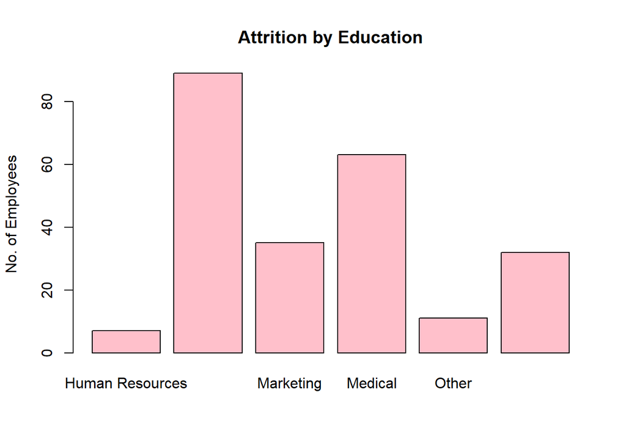

```r
barplot(table(att$EducationField[att$Attrition == 1]),  ylab = 'No. of Employees',
        main = 'Attrition by Education',
        col = "Pink")
```

Arguments: Null hypothesis is rejected emplyoees having life sciences as education have more attrition rate.

### HYPOTHESIS 9:-

#### Attrition by Years at the current company

Null Hyp = Employees having high number of years in the current company might have high attrition rate

ALternate Hyp < > Employees having high number of years in the current company does not have high attrition rate

Approach - Using histogram to plot this

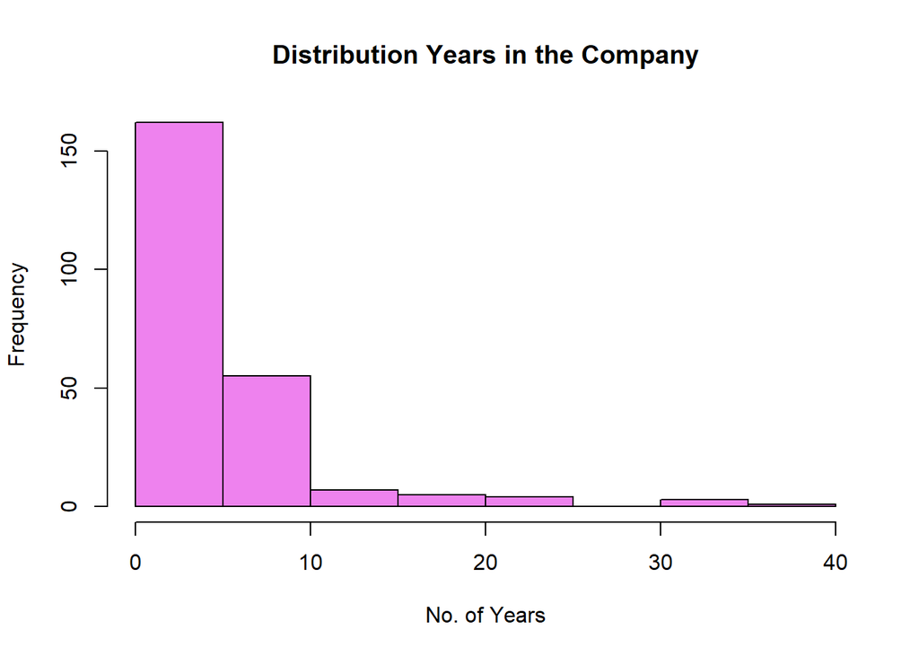

```r
hist(att$YearsAtCompany[att$Attrition == 1], xlab = 'No. of Years', main = 'Distribution Years in the Company', col = "Violet")
```

Arguments: NULL hypothesis is rejected because people with less number of years in the current organisation have high attrition rate

## Concluding note:-

### From this EDA analysis, it is observed that the :

1. Mid age group 25-35 have high attrition rate
2. Male employees are contributing more to the attrition which could be possibly because of high number male employees in the company 3.Distance from the office doesnt help here either as high numbber of people with very close home location to the office have also shown high attrition rate
3. Also, In education - Life sciences, Years in the company - less, Departent - R&D, Monthly salary - low have high attrition rate